# In-Class Exercises 1-21

# 1. Random Variables & Distributions

Warm‑up (no code)

1. In your own words, what is a random variable?
2. What does it mean to say a variable follows a normal distribution?

```r
# Draw 1,000 observations from a normal distribution
```

## Task 1: Compute the mean and standard deviation of your observations manually using mean() and sd().

- How close are they to the values we specified (50 and 10)?

```r
# calculate the mean and standard deviation
```

Discussion:

- Why aren’t the sample values exactly 50 and 10?

## Task 2: Visualizing the Distribution

```r
# create a histogram of your simulated data
```

Group discussion questions:

- Is the distribution symmetric?
- Where is most of the mass concentrated?

# 2. Probability & Events

Concept check

Suppose:

- $P(A) = 0.4$
- $P(B) = 0.3$
- $P(A \cap B) = 0.1$
- Compute $P(A \cup B)$.
- Are A and B independent? Why or why not?

## Task 3: Empirical Probabilities via Simulation

```r
# Roll a die 10,000 times and save the sample



# Calculate the probability of rolling a 6 from your sample
```

Next:

- Estimate the probability of rolling an even number from your sample.
- Estimate P(roll ≥ 4).

```r
# probability of rolling an even number

# probability P(roll >= 4)
```

Discussion:

- Why do these values get closer to the theoretical probabilities as sample size increases?

# 3. Law of Large Numbers

## Task 4: Convergence of Sample Means

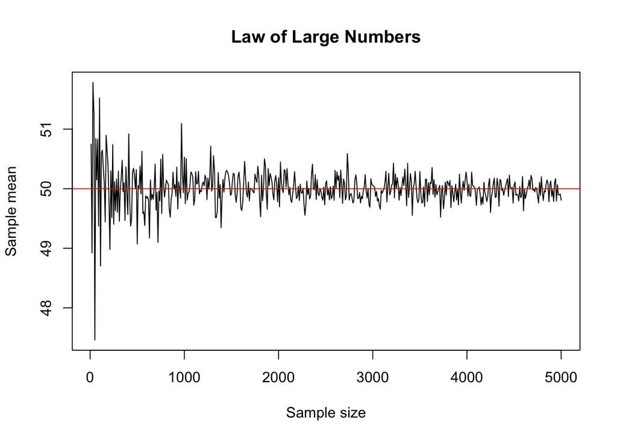

```r
# Generate increasing sample sizes
n <- seq(10, 5000, by = 10)
means <- sapply(n, function(i) mean(rnorm(i, 50, 10)))



plot(n, means, type = "l",
main = "Law of Large Numbers",
xlab = "Sample size",
ylab = "Sample mean")
abline(h = 50, col = "red")
```

Questions

1. What happens to the sample mean as n grows?
2. Why does this matter for empirical research?

# 4. Central Limit Theorem

## Task 5: Sampling Distribution of the Mean

```r
# Draw 1000 sample means from a skewed distribution
sample_means <- replicate(1000, mean(rexp(40)))

# create a histogram of the sample means
```

Group discussion

- Is the original distribution normal?
- Is the sampling distribution approximately normal?
- Why is this result important for inference?

# 5. Descriptive Statistics

## Task 6: Working with Real Data

```r
# add the mtcars data to your R session
```

Next:

- Compute mean, median, and standard deviation of `mpg`.
- Interpret each statistic.

```r
# mean

# median

# sd
```

## Task 7: Group Comparisons

```r
# Compare the mean mpg for automatic vs manual transmission
```

Questions:

- Which group has higher fuel efficiency?
- Is this a causal claim? Why or why not?

# 6. Covariance & Correlation

## Task 8: Correlation in Practice

```r
# calculate the correlation between horsepower (hp) and mpg
```

Questions:

- Is this relationship positive or negative?
- How strong is it using the correlation guidelines?

## Task 9: Visualizing Correlation

```r
# create a scatterplot with horsepower on the x-axis and mpg on the y-axis
# draw a regression line through the scatterplot
```

Discussion:

- Does the plot match the correlation sign?
- What patterns do you see?

# 7. Reflection & Wrap‑Up

- **What did simulation help you understand today?**
- **Which concept (LLN, CLT, correlation, etc.) still feels fuzzy?**
- **How could these tools apply to your own research questions?**